# Differential expression LGR5+ Colon vs SI

Jason T. Serviss

2018-06-04

```r
#PACKAGES
packages <- c("sp.scRNAseq", "sp.scRNAseqData", "ggthemes", "tidyverse", "seqTools")
purrr::walk(packages, library, character.only = TRUE)
rm(packages)
```

### Goal

Identify DE genes between colon and SI stem cells via single cell RNA-seq data from mouse. This was perfored using 2 different strategies: a) pairwise comparison of all cell types as defined by unsupervised classification and b) comparison of the top 50 Lgr5+ colon vs small intestine cells from the stem cell population (as defined above).

### Run unsupervised classification

First we run unsupervised classificaiton using t-SNE and the Mclust software.

```r
#setup spCounts
s <- str_detect(colnames(countsMgfp), "^s")
countsMgfpMeta <- countsMgfpMeta %>%
mutate(mouseName = if_else(
  str_detect(plate, "NJA004"),
  "C57black/6J", "C57black/6J/Lgr5gfp"
  ))
 m <- colnames(countsMgfp) %in% filter(countsMgfpMeta, mouseName == "C57black/6J")$sample

cObjSng <- spCounts(countsMgfp[, s & m], cbind(countsMgfpERCC[, s & m]))
cObjMul <- spCounts(countsMgfp[, !s & m], cbind(countsMgfpERCC[, !s & m]))

#spUnsupervised
uObj <- spUnsupervised(cObjSng, max_iter = 7000, initial_dims = sum(s), max = 250, perplexity = 7, seed = 73223)
save(uObj, file = "uObj.rda")
#load("~/Github/sp.scRNAseqTesting/inst/testingPoissonAlgo/uObj.rda")
```

Plot unsupervised classification results.

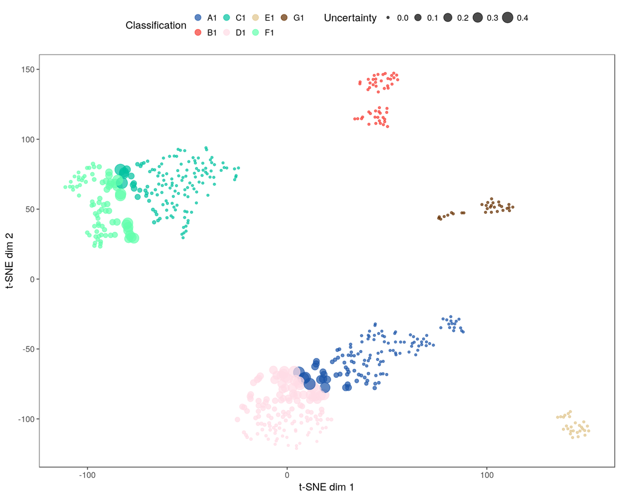

```r
plotUnsupervisedClass(uObj, cObjSng)
```

Show marker expression specific for the cell types in the tissue.

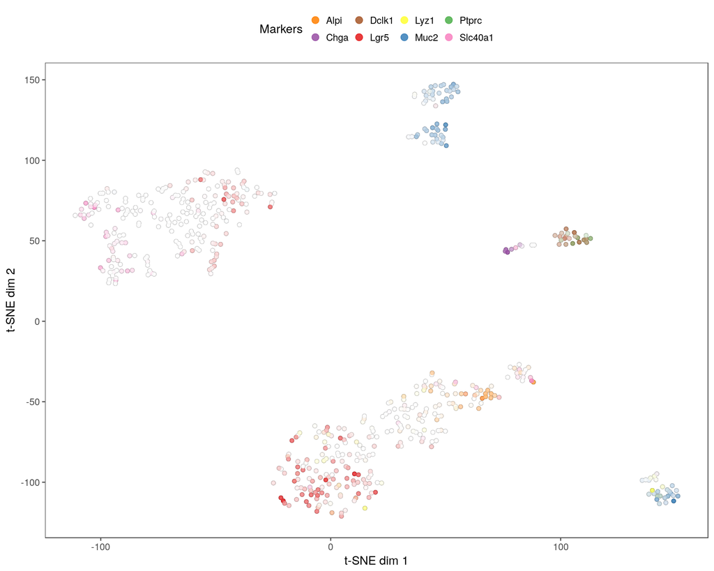

```r
plotUnsupervisedMarkers(
  uObj, cObjSng,
  c("Lgr5", "Muc2", "Ptprc", "Chga", "Alpi", "Lyz1", "Dclk1", "Slc40a1"),
  pal = RColorBrewer::brewer.pal(8, "Set1")
)
```

Show the tissues.

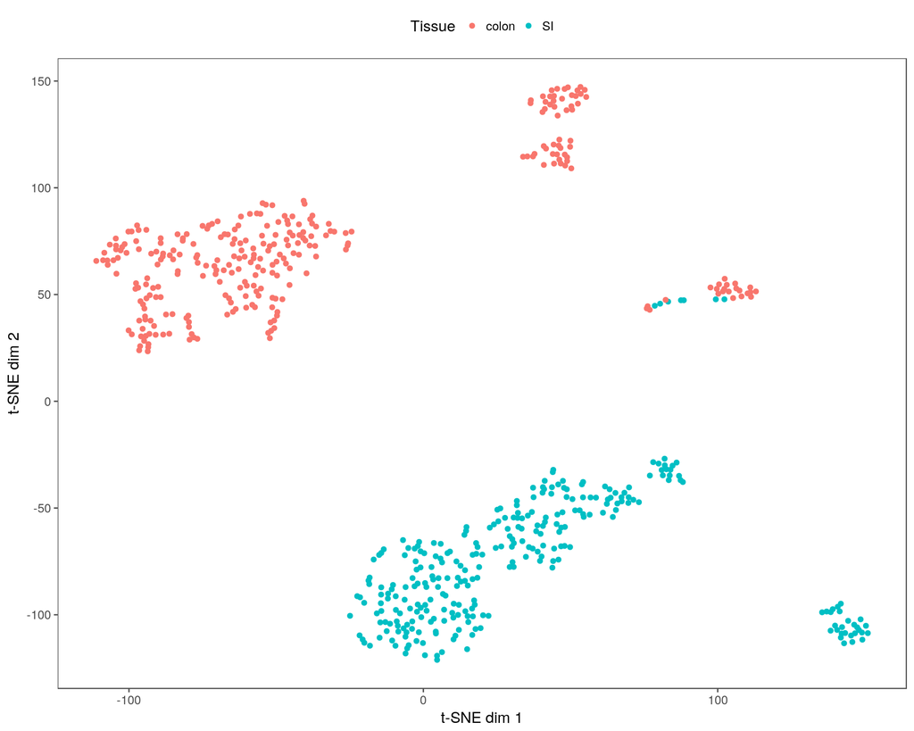

```r
plotUnsupervisedClass(uObj, cObjSng) %>%
plotData() %>%
inner_join(countsMgfpMeta, by = c("Sample" = "sample")) %>%
ggplot() +
geom_point(aes(`t-SNE dim 1`, `t-SNE dim 2`, colour = tissue)) +
theme_few() +
theme(legend.position = "top") +
guides(colour = guide_legend(title = "Tissue"))
```

Rename the classes

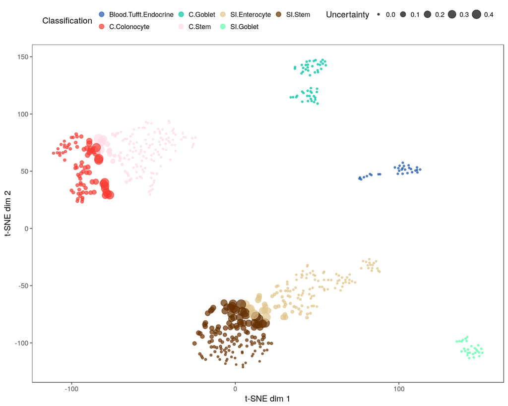

```r
classifications <- tibble(
  sample = rownames(getData(uObj, "tsne")),
  oldClass = getData(uObj, "classification")
) %>%
mutate(newClass = case_when(
  oldClass == "C1" ~ "C.Stem",
  oldClass == "F1" ~ "C.Colonocyte",
  oldClass == "B1" ~ "C.Goblet",
  oldClass == "G1" ~ "Blood.Tufft.Endocrine",
  oldClass == "D1" ~ "SI.Stem",
  oldClass == "A1" ~ "SI.Enterocyte",
  oldClass == "E1" ~ "SI.Goblet",
  TRUE ~ "error"
))

#write_tsv(classifications, path = "~/Github/sp.scRNAseqTesting/inst/differentialExpLgr5ColonSI/classes.txt")
#classifications <- read_tsv("/home/Github/sp.scRNAseqTesting/inst/differentialExpLgr5ColonSI/classes.txt")
classification(uObj) <- classifications$newClass[match(rownames(getData(uObj, "tsne")), classifications$sample)]
groupMeans(uObj) <- averageGroupExpression(cObjSng, getData(uObj, "classification"), FALSE)
tsneMeans(uObj) <- tsneGroupMeans(getData(uObj, "tsne"), getData(uObj, "classification"))
plotUnsupervisedClass(uObj, cObjSng)
```

Show Lgr5 expression.

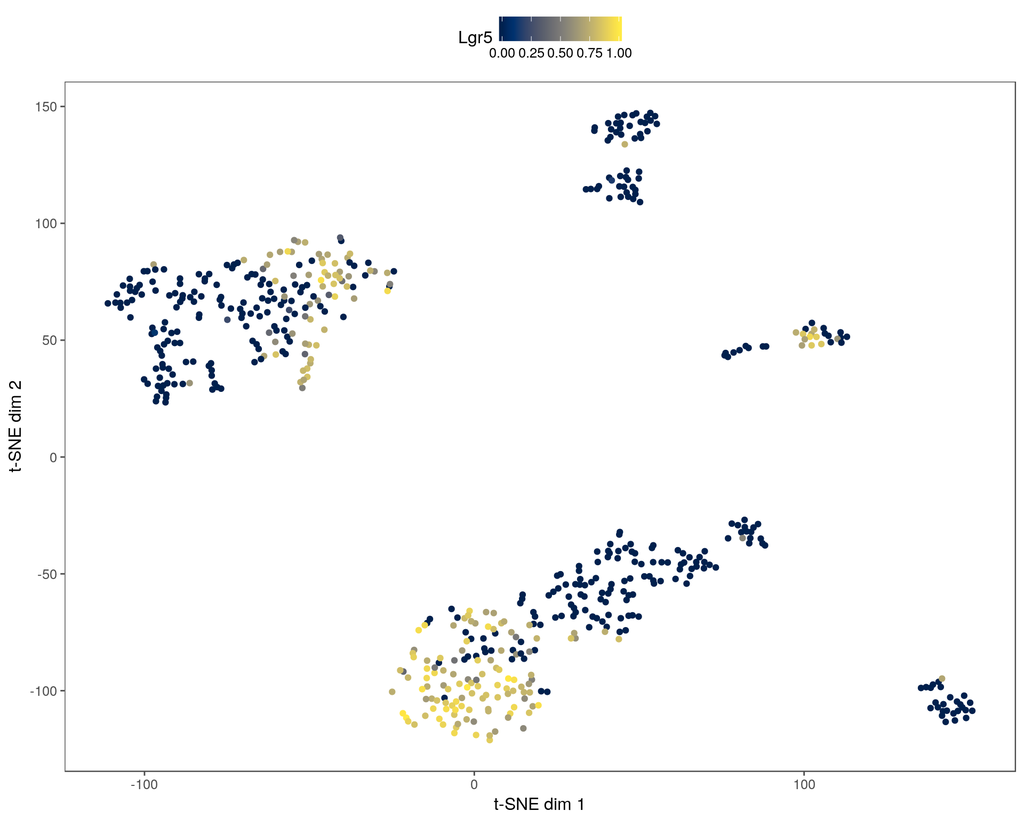

```r
plotUnsupervisedMarkers(uObj, cObjSng, "Lgr5")
```

Expression is log2(cpm) and then scaled to the interval [0, 1] with: (exp - min(exp)) / (max(exp) - min(exp)).

Show Lgr5 expression per class and tissue.

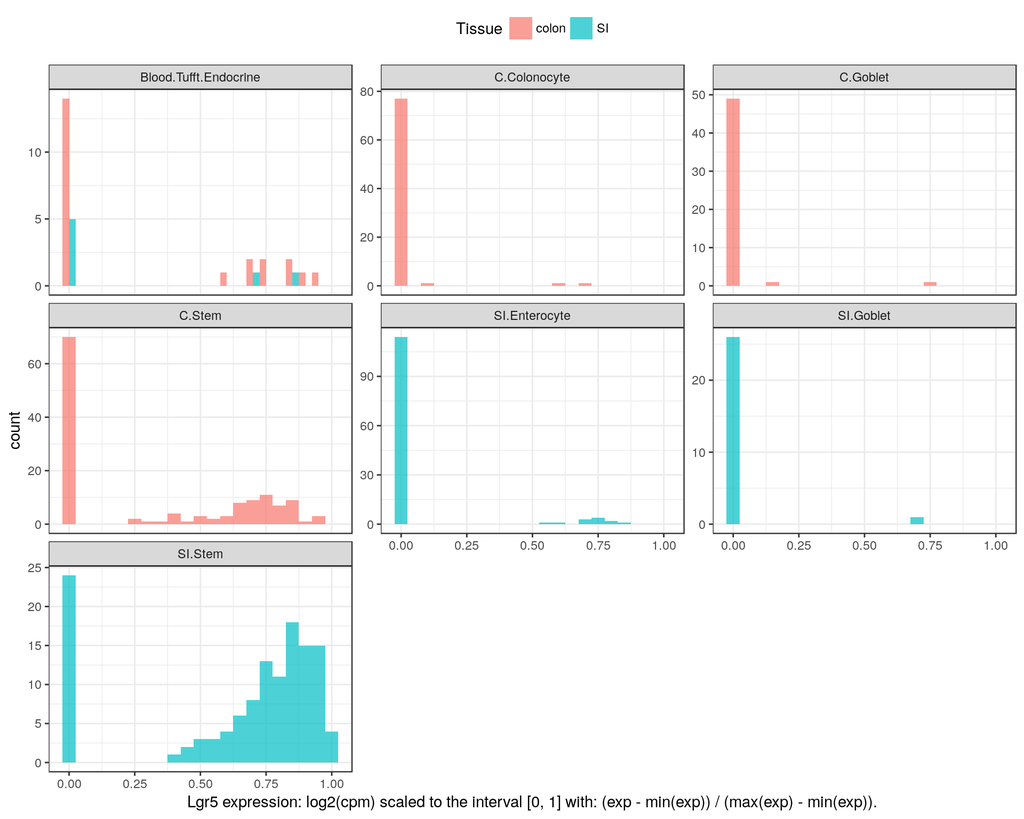

```r
plotUnsupervisedMarkers(uObj, cObjSng, "Lgr5") %>%
plotData() %>%
inner_join(countsMgfpMeta, by = c("Sample" = "sample")) %>%
ggplot() +
geom_histogram(
  aes(Lgr5, fill = tissue, y = ..count.., group = tissue), binwidth = 0.05, position = position_dodge(),
  alpha = 0.7
) +
facet_wrap(~Classification, scales = "free_y") +
theme_bw() +
theme(legend.position = "top", plot.caption = element_text(hjust = 0)) +
guides(fill = guide_legend(title = "Tissue")) +
labs(
  x = "Lgr5 expression: log2(cpm) scaled to the interval [0, 1] with: (exp - min(exp)) / (max(exp) - min(exp))."
)
```

### Differential expression strategy 1

Pairwise KStest using all classes.

```r
ks.res <- KStest(getData(cObjSng, "counts.cpm"), getData(uObj, "classification"), cores = 8)
p.ks.res <- processKStest(ks.res, getData(uObj, "classification"), 0.05) %>%
filter(sigBool) %>%
group_by(gene) %>%
filter(n() == 1) %>%
ungroup() %>%
mutate(p.prod = map_dbl(p.values, prod))
```

Number of significant genes detected at alpha 0.05?

```r
p.ks.res %>% count(id)
```

```
## # A tibble: 7 x 2
##   id                        n
##   <chr>                 <int>
## 1 Blood.Tufft.Endocrine   374
## 2 C.Colonocyte            133
## 3 C.Goblet                 90
## 4 C.Stem                   38
## 5 SI.Enterocyte           213
## 6 SI.Goblet                70
## 7 SI.Stem                 158
```

Number of significant genes detected at alpha 0.01?

```r
processKStest(ks.res, getData(uObj, "classification"), 0.01) %>%
filter(sigBool) %>%
group_by(gene) %>%
filter(n() == 1) %>%
ungroup() %>%
mutate(p.prod = map_dbl(p.values, prod)) %>%
count(id)
```

```
## # A tibble: 7 x 2
##   id                        n
##   <chr>                 <int>
## 1 Blood.Tufft.Endocrine   240
## 2 C.Colonocyte             95
## 3 C.Goblet                 56
## 4 C.Stem                   25
## 5 SI.Enterocyte           126
## 6 SI.Goblet                39
## 7 SI.Stem                  92
```

Number of significant genes detected at alpha 0.001?

```r
processKStest(ks.res, getData(uObj, "classification"), 0.001) %>%
filter(sigBool) %>%
group_by(gene) %>%
filter(n() == 1) %>%
ungroup() %>%
mutate(p.prod = map_dbl(p.values, prod)) %>%
count(id)
```

```
## # A tibble: 7 x 2
##   id                        n
##   <chr>                 <int>
## 1 Blood.Tufft.Endocrine   149
## 2 C.Colonocyte             59
## 3 C.Goblet                 31
## 4 C.Stem                   22
## 5 SI.Enterocyte            74
## 6 SI.Goblet                21
## 7 SI.Stem                  67
```

Number of significant genes detected at alpha 0.05 and fold change > 2?

```r
p.ks.res <- p.ks.res %>%
mutate(meanCpm = map2_dbl(id, gene, function(i, g) {
  mean(getData(cObjSng, "counts.cpm")[g, getData(uObj, "classification") == i])
})) %>%
mutate(log2.fc = map2_dbl(id, gene, function(i, g) {
  log2(
    mean(getData(cObjSng, "counts.cpm")[g, getData(uObj, "classification") == i]) /
    mean(getData(cObjSng, "counts.cpm")[g, getData(uObj, "classification") != i])
  )
})) %>%
arrange(desc(log2.fc), p.prod, desc(statSum), desc(meanCpm))
save(p.ks.res, file = './differentialExpressionStrategy1.rda', compress = "bzip2")
p.ks.res %>%
filter(log2.fc > 1 | log2.fc < -1) %>%
count(id)
```

```
## # A tibble: 7 x 2
##   id                        n
##   <chr>                 <int>
## 1 Blood.Tufft.Endocrine   347
## 2 C.Colonocyte             79
## 3 C.Goblet                 77
## 4 C.Stem                   17
## 5 SI.Enterocyte           126
## 6 SI.Goblet                60
## 7 SI.Stem                  66
```

Plot some candidates in the context of all cells.

```r
#dotplot function
dotplot <- function(data) {
  data %>%
  rename(Gene = gene) %>%
  ggplot() +
  #geom_boxplot(aes(Classification, expression, colour = Gene, group = Classification), outlier.shape = NA) +
  geom_dotplot(
    data = . %>% filter(expression != 0),
    aes(Classification, expression, colour = Gene, fill = Gene, group = interaction(Classification, Gene)),
    binaxis="y", stackdir="center", binwidth = 0.01, position = position_dodge()
  ) +
  geom_text(
    data = . %>%
      group_by(Classification, Gene) %>%
      summarize(do = paste0(round(length(which(expression == 0)) / n(), digits = 2) * 100, "%")),
    aes(Classification, 0.05, label = do), size = 2
  ) +
  geom_point(
    data = . %>%
      group_by(Gene, Classification) %>%
      summarize(median = median(expression)) %>%
      filter(median != 0),
    aes(Classification, median), shape = 95, size = 3
  ) +
  ylim(0, 1) +
  theme_few() +
  theme(axis.text.x = element_text(angle = 90), legend.position = "top") +
  facet_wrap(~Gene) +
  labs(
    x = "Tissue",
    y = "log2(expression)[0, 1]"
  ) +
  guides(fill = FALSE, colour = FALSE)
}
```

SI stem genes

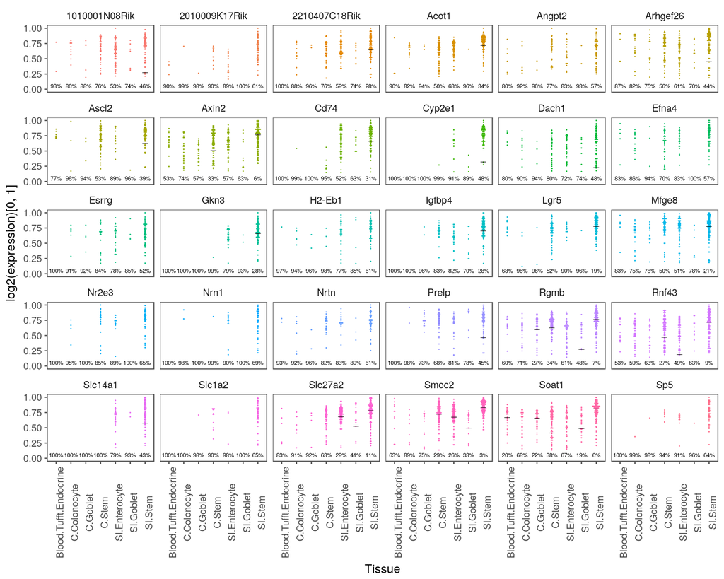

```r
#plot SI candidates
p.ks.res %>%
filter(id == "SI.Stem") %>%
arrange(desc(log2.fc), p.prod, desc(statSum), desc(meanCpm)) %>%
slice(1:30) %>%
pull(gene) %>%
plotUnsupervisedMarkers(uObj, cObjSng, .) %>%
plotData() %>%
gather(gene, expression, -(Sample:Colour)) %>%
dotplot()
```

Colon stem genes

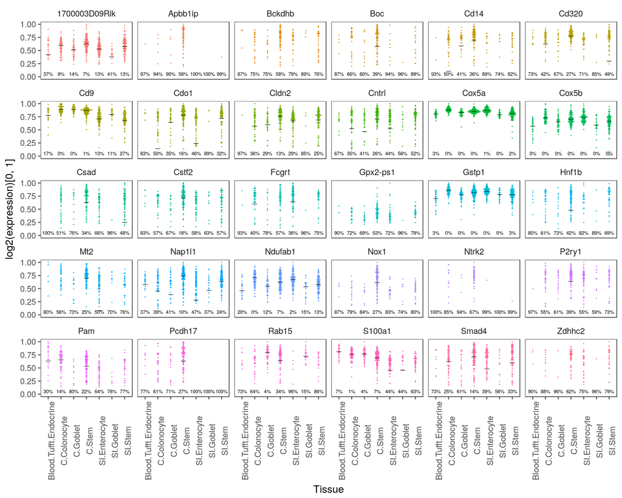

```r
p.ks.res %>%
filter(id == "C.Stem") %>%
arrange(desc(log2.fc), p.prod, desc(statSum), desc(meanCpm)) %>%
slice(1:30) %>%
pull(gene) %>%
plotUnsupervisedMarkers(uObj, cObjSng, .) %>%
plotData() %>%
gather(gene, expression, -(Sample:Colour)) %>%
dotplot()
```

### Differential expression strategy 2

KStest using only the top 50 cells in each of the C.Stem and S.Stem classes with highest Lgr5 and comparing only these classes.

```r
idx <- which(getData(uObj, "classification") %in% c("C.Stem", "SI.Stem"))
counts <- getData(cObjSng, "counts.cpm")[, idx]
classes <- getData(uObj, "classification")[idx]

#find top 50 cells in each class with highest Lgr5
top50 <- tibble(Lgr5 = counts["Lgr5", ], class = classes, sample = colnames(counts)) %>%
group_by(class) %>%
top_n(50, Lgr5) %>%
ungroup()

ks.res2 <- KStest(counts[, match(top50$sample, colnames(counts))], top50$class, cores = 8)
p.ks.res2 <- ks.res2 %>%
filter(p.value < 0.001) %>%
separate(combination, c("Celltype1", "Celltype2"), sep = "-")
```

Number of significant genes detected at alpha 0.05?

```r
ks.res2 %>%
filter(p.value < 0.05) %>%
count(combination)
```

```
## # A tibble: 1 x 2
##   combination        n
##   <chr>          <int>
## 1 C.Stem-SI.Stem  1160
```

Number of significant genes detected at alpha 0.01?

```r
ks.res2 %>%
filter(p.value < 0.01) %>%
count(combination)
```

```
## # A tibble: 1 x 2
##   combination        n
##   <chr>          <int>
## 1 C.Stem-SI.Stem   536
```

Number of significant genes detected at alpha 0.001?

```r
ks.res2 %>%
filter(p.value < 0.001) %>%
count(combination)
```

```
## # A tibble: 1 x 2
##   combination        n
##   <chr>          <int>
## 1 C.Stem-SI.Stem   274
```

```r
p.ks.res2 <- p.ks.res2 %>%
mutate(
  meanCpmCelltype1 = map2_dbl(Celltype1, gene, function(i, g) {
    mean(getData(cObjSng, "counts.cpm")[g, getData(uObj, "classification") == i])
  }),
  meanCpmCelltype2 = map2_dbl(Celltype2, gene, function(i, g) {
    mean(getData(cObjSng, "counts.cpm")[g, getData(uObj, "classification") == i])
  })
) %>%
mutate(log2.fc = log2(meanCpmCelltype1 / meanCpmCelltype2)) %>%
arrange(desc(log2.fc), p.value)
save(p.ks.res2, file = './differentialExpressionStrategy2.rda', compress = "bzip2")
p.ks.res2 %>%
filter(log2.fc > 1 | log2.fc < -1) %>%
unite(combination, Celltype1, Celltype2) %>%
count(combination)
```

```
## # A tibble: 1 x 2
##   combination        n
##   <chr>          <int>
## 1 C.Stem_SI.Stem   195
```

Plot some candidates in the context of all cells.

SI stem genes

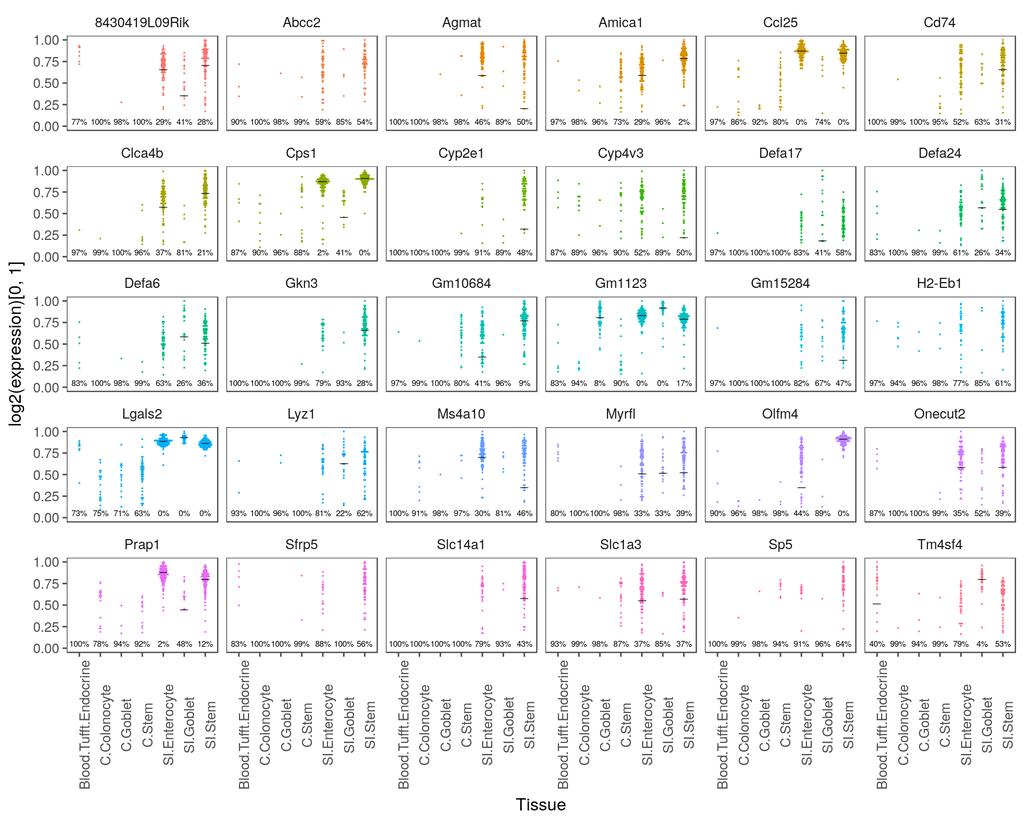

```r
p.ks.res2 %>%
filter(log2.fc < 1) %>%
arrange(log2.fc, p.value) %>%
slice(1:30) %>%
pull(gene) %>%
plotUnsupervisedMarkers(uObj, cObjSng, .) %>%
plotData() %>%
gather(gene, expression, -(Sample:Colour)) %>%
dotplot()
```

Colon stem genes

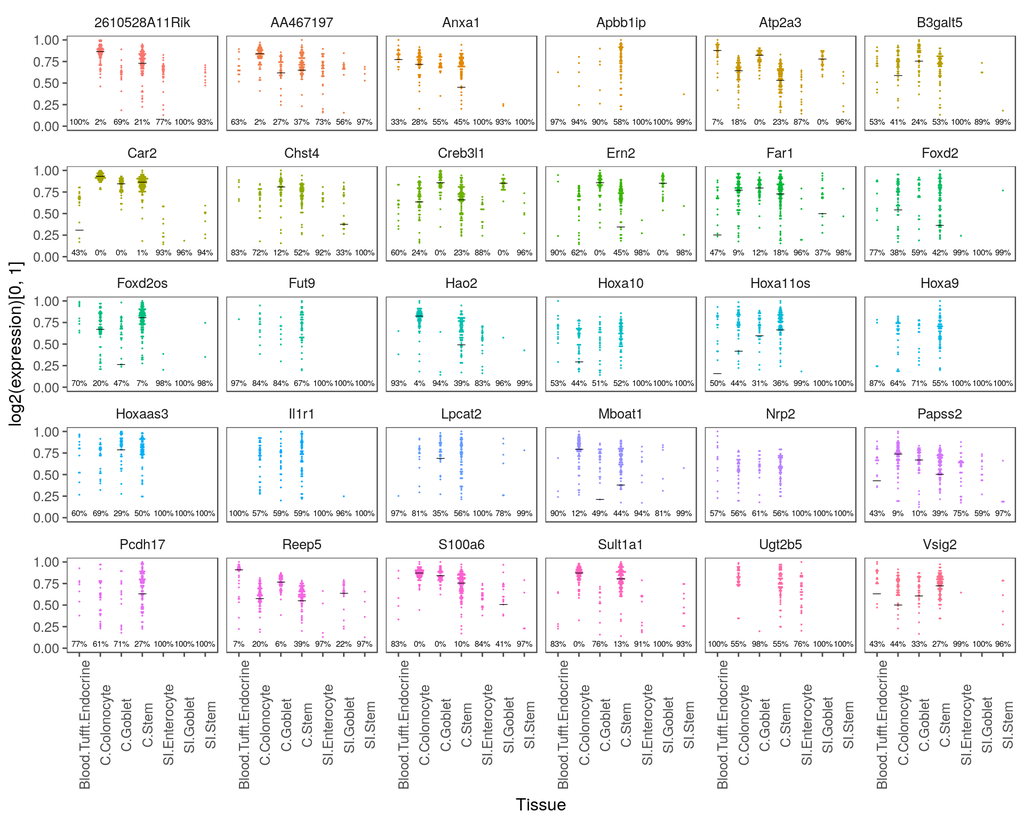

```r
p.ks.res2 %>%
filter(log2.fc > 1) %>%
arrange(desc(log2.fc), p.value) %>%
slice(1:30) %>%
pull(gene) %>%
plotUnsupervisedMarkers(uObj, cObjSng, .) %>%
plotData() %>%
gather(gene, expression, -(Sample:Colour)) %>%
dotplot()
```

Results were saved to the file “differentialExpressionStrategy2” with the following columns:

Cell type 1: 1st cell type in comparison Cell type 2: 2nd cell type in comparison Gene: the name of the gene Stat: the test statistic from the KS test that was performed for the corresponding gene p.value: the p values from the KS test that was performed for the corresponding gene meanCpmCellType1: mean counts per million for cell type 1 meanCpmCellType2: mean counts per million for cell type 2 Log2.fc: the log 2 fold change comparing the two cell types.